# Lecture 5: Introduction to bulk-RNAseq DE Analysis: Statistical Analysis

Megan Stumpf

10/05/2022

# 1. Objectives and Goals

The primary objective of this assignment is to illustrate that you understand the final steps of bulk-RNAseq data processing as it pertains to data clean up, modeling and differential gene expression analysis. By the end of this lecture and assignment you should be able to:

- use `DESeq2` for count normalization and differential gene expression analysis
- use `prcomp` to perform PCA
- generate and interpret PCA plots in order to identify potential covariates or batch effects
- generate and interpret QC plots for differential expression analysis
- perform DE analysis between different biological groups

```r
knitr::opts_chunk$set(echo = TRUE)
```

# 2. Install/Load packages

This section is always required. You will load all packages necessary for the scope of the assignment in between the code blocks.

Write code to load in the following R packages:

- tidyverse
- DESeq2

```r
# TO DO
library(tidyverse)
library(DESeq2)
library(ggrepel)
```

# 3. Bulk RNA-seq Statitical Analysis

**Purpose**: To understand and be able read in your data to generate a counts matrix with approriately linked metadata for differential gene expression analysis. Additionally, this will help you walk through how to think through and filter out data, why we use negative binomial distributions to model RNA seq counts data, and how to execute the statistics in order to perform differential gene expression analysis.

## 3.1 Prepare data for DESeq2

1. Perform the following tasks as they pertain loading in data and confirming data set up is correct
1. Read in your csv metadata file and store it in a variable called metadata
2. Load in your counts matrix, extract the counts portions and store that in a variable called geneCounts
3. Set the rownames of the metadata frame to be the same as the column names in the counts matrix and confirm they are equal, if they are not equal manipulate the dataframe to ensure they are
4. Write a line of code to show the five-number summary and mean for each set of raw counts per sample.

```r
# TO DO
#A
metadata <- read.csv(file = "~/assignments/bulk_RNAseq_data_qc_metrics_for_students_updated.csv", header = TRUE, sep = ",")

#B
load("~/bulkRNAseq/count_files/myQuantificationResults.rdat")
geneCounts <- myCounts$counts

#C
##Have to go back and rename the bam files and rerun the counts matrix because my assigned samples were not properly named when generating the .bam files
rownames(metadata) <- metadata$short_sample_ID
colnames(geneCounts) <- rownames(metadata)
all(rownames(metadata) == colnames(geneCounts))
```

```
## [1] TRUE
```

```r
all(rownames(metadata) %in% colnames(geneCounts))
```

```
## [1] TRUE
```

```r
#D
summary(geneCounts)
```

```
##  0_min_unstimulated_rep1 0_min_unstimulated_rep2 0_min_unstimulated_rep3
##  Min.   :      0.0       Min.   :     0.0        Min.   :     0.0
##  1st Qu.:      0.0       1st Qu.:     0.0        1st Qu.:     0.0
##  Median :      5.0       Median :     2.0        Median :     3.0
##  Mean   :   1255.2       Mean   :   404.2        Mean   :   369.2
##  3rd Qu.:    591.5       3rd Qu.:   181.0        3rd Qu.:   190.5
##  Max.   :1182960.0       Max.   :197907.0        Max.   :204817.0
##  30_min_N4_peptide_PRN-694_rep1 30_min_N4_peptide_PRN-694_rep2
##  Min.   :     0                 Min.   :    0
##  1st Qu.:     0                 1st Qu.:    0
##  Median :     3                 Median :    1
##  Mean   :   689                 Mean   :  260
##  3rd Qu.:   374                 3rd Qu.:  141
##  Max.   :450393                 Max.   :77781
##  30_min_N4_peptide_PRN-694_rep3 30_min_unstimulated_rep1
##  Min.   :     0.0               Min.   :     0.0
##  1st Qu.:     0.0               1st Qu.:     0.0
##  Median :     2.0               Median :     3.0
##  Mean   :   246.3               Mean   :   697.3
##  3rd Qu.:   152.0               3rd Qu.:   320.0
##  Max.   :209566.0               Max.   :606330.0
##  30_min_unstimulated_rep2 30_min_unstimulated_rep3 30_min_N4_peptide_rep1
##  Min.   :     0.0         Min.   :     0.0         Min.   :     0.0
##  1st Qu.:     0.0         1st Qu.:     0.0         1st Qu.:     0.0
##  Median :     2.0         Median :     2.0         Median :     4.0
##  Mean   :   353.7         Mean   :   304.1         Mean   :   844.2
##  3rd Qu.:   160.0         3rd Qu.:   150.0         3rd Qu.:   473.0
##  Max.   :142574.0         Max.   :214685.0         Max.   :236427.0
##  30_min_N4_peptide_rep2 30_min_N4_peptide_rep3
##  Min.   :    0.0        Min.   :     0
##  1st Qu.:    0.0        1st Qu.:     0
##  Median :    2.0        Median :     2
##  Mean   :  326.9        Mean   :   279
##  3rd Qu.:  172.5        3rd Qu.:   158
##  Max.   :86378.0        Max.   :419406
```

## 3.2 Filtering and normalization

2. Perform the following tasks as they pertain to pre-filtering data, generating a DESeq2 data object, normalization, and accessing normalized counts
1. Filter out any genes where the raw counts across all samples is less than 10 and generate a new counts matrix
2. Create a DESeq2 object using biological_groups as the outcome to test and place your filtered data, metadata, and design as a deseq2 data object
3. Apply the normalization
4. Extract the normalized counts and store them in a variable
5. Save your normalized counts file as a csv file with whatever file name of your choice for later use

```r
# TO DO

#A
keep <- rowSums(geneCounts) >= 10
filteredGeneCounts <- geneCounts[keep, ]

#B
deData <- DESeqDataSetFromMatrix(countData = filteredGeneCounts, colData = metadata, design = ~ biological_groups)
```

```
##   Note: levels of factors in the design contain characters other than
##   letters, numbers, '_' and '.'. It is recommended (but not required) to use
##   only letters, numbers, and delimiters '_' or '.', as these are safe characters
##   for column names in R. [This is a message, not a warning or an error]
```

```r
#C
deData <- DESeq(deData)
```

[output not shown]

[output not shown]

[output not shown]

```r
#D
normCountsDf <- counts(deData, normalized = TRUE)

#E
save(normCountsDf, file = "~/bulkRNAseq/L5/normCounts.csv")
```

## 3.3 PCA

3. Perform the following tasks as they pertain to PCA and data exploration to identify covariates
1. Run PCA on your normalized counts and store the resulting data object into a variable
2. Merge your PCs dataframe with your metadata dataframe
3. Generate the following 4 plots:
- PC1 vs PC2 colored by biological groups
- PC2 vs PC3 colored by biological groups
- PC1 vs PC2 colored by replicate
- PC2 vs PC3 colored by replicate

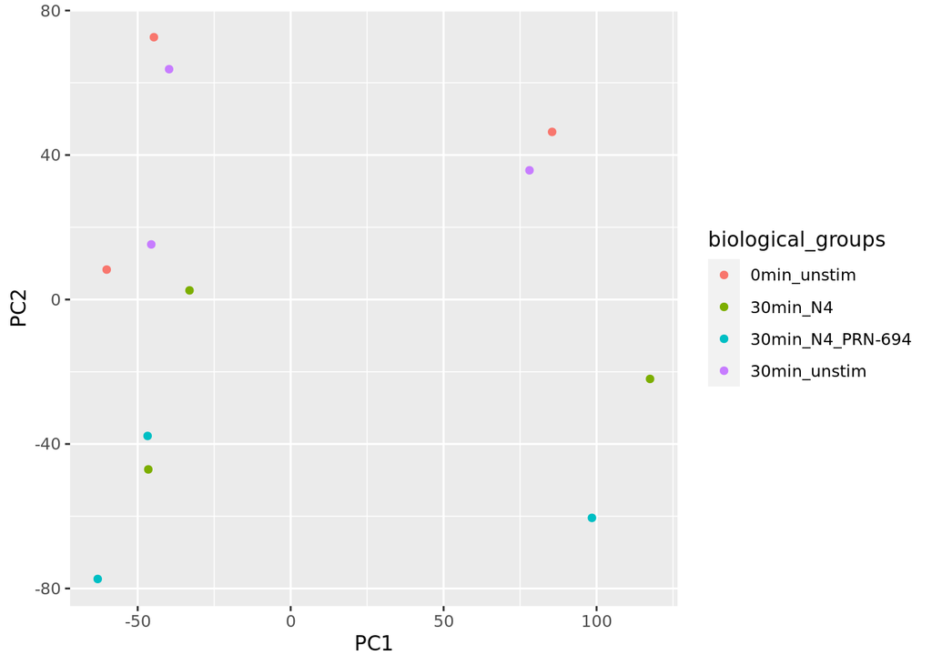

```r
# TO DO

#A
pcs <- prcomp(t(normCountsDf), scale. = TRUE)

#B
metadata <- cbind(pcs$x, metadata)

#C
##Plot Generation
ggplot(metadata, aes(x = PC1, y = PC2, color = biological_groups)) + geom_point()
```

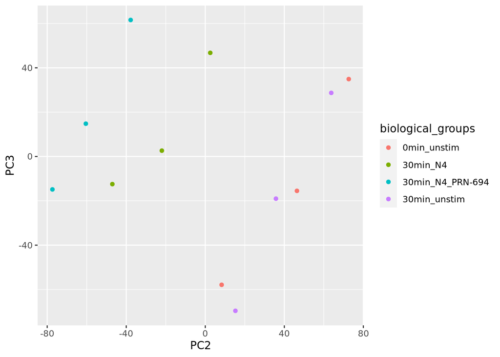

```r
ggplot(metadata, aes(x = PC2, y = PC3, color = biological_groups)) + geom_point()
```

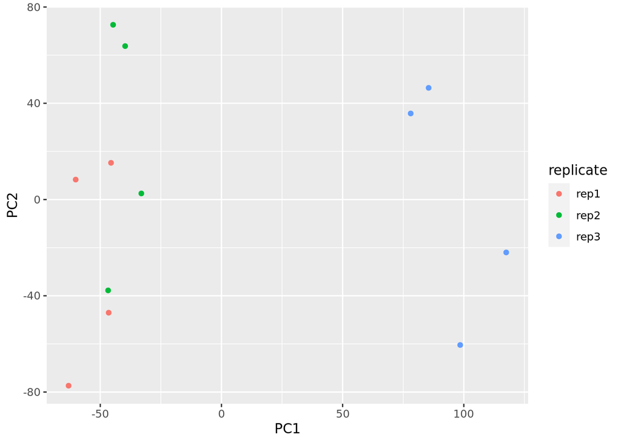

```r
ggplot(metadata, aes(x = PC1, y = PC2, color = replicate)) + geom_point()
```

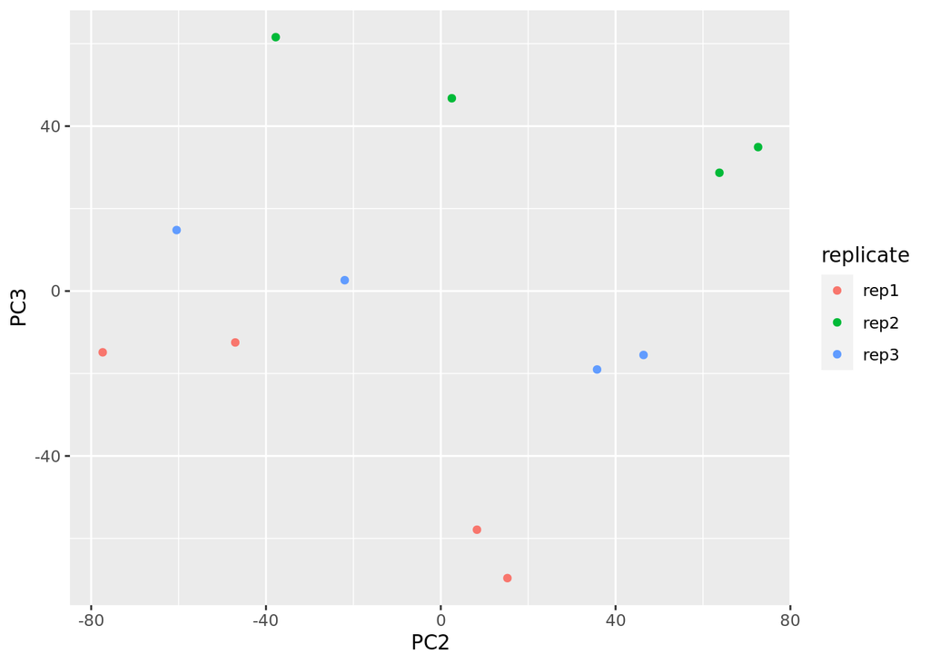

```r
ggplot(metadata, aes(x = PC2, y = PC3, color = replicate)) + geom_point()
```

## 3.4 Reassessing GLM

4. Perform the following tasks as they pertain to modifying your GLM and re-normalizing your data set
1. Update your design formula (GLM) to now include PC1 as a covariate
2. Renormalize your data with the updated design formula and model
3. Extract and save your normalized counts to a csv file

```r
# TO DO

#A
deData2 <- DESeqDataSetFromMatrix(countData = filteredGeneCounts, colData = metadata, design = PC1 ~ biological_groups)
```

```
##   the design formula contains one or more numeric variables that have mean or
##   standard deviation larger than 5 (an arbitrary threshold to trigger this message).
##   Including numeric variables with large mean can induce collinearity with the intercept.
##   Users should center and scale numeric variables in the design to improve GLM convergence.
```

[output not shown]

```r
#B
deData2 <- DESeq(deData2)
```

[output not shown]

[output not shown]

[output not shown]

```r
#C
normCountsDf2 <- counts(deData2, normalized = TRUE)
save(normCountsDf2, file = "~/bulkRNAseq/L5/normCounts2.csv")
```

## 3.5 Differential gene expression analysis

5. Perform the following tasks as they pertain to differential gene expression analysis:
1. perform differential gene expression analysis comparing the 30min_N4_PRN-694 biological group relative to the 30min_N4 biological group
2. generate a histogram of unadjusted p-values for the above comparison and a Cook’s distance boxplot of all samples
3. write a line or two of code to save the results files dataframe to a csv file
4. repeat step (a)-(c) but this time for the 30min_N4 group relative to the 30min_unstim group

```r
# TO DO

myResults <- results(object = deData2, contrast = c("biological_groups", "30min_N4_PRN-694", "30min_N4"))
myResults
```

```
## log2 fold change (MLE): biological_groups 30min_N4_PRN-694 vs 30min_N4
## Wald test p-value: biological_groups 30min_N4_PRN-694 vs 30min_N4
## DataFrame with 14247 rows and 6 columns
##                 baseMean log2FoldChange     lfcSE       stat     pvalue
##                <numeric>      <numeric> <numeric>  <numeric>  <numeric>
## Zc3h14         375.46102      0.1229047  0.197372  0.6227046   0.533479
## Troap            4.08663      0.1063294  1.385897  0.0767224   0.938844
## 1810013L24Rik  842.63712      0.6870748  0.487308  1.4099398   0.158557
## Srsf7         4222.63692     -0.0381505  0.212885 -0.1792070   0.857775
## Anapc15        371.16626     -0.2353785  0.166811 -1.4110466   0.158231
## ...                  ...            ...       ...        ...        ...
## Tpm4          3634.67887      -0.454243  0.167516  -2.711634 0.00669524
## Oxgr1            2.79668      -0.550987  1.217288  -0.452635 0.65081167
## Gm10130         83.14188       0.909199  0.299220   3.038564 0.00237709
## Thoc2l         476.81530      -0.137139  0.409414  -0.334965 0.73765155
## Paqr9            1.21841      -0.392719  2.311901  -0.169869 0.86511353
##                    padj
##               <numeric>
## Zc3h14         0.999396
## Troap                NA
## 1810013L24Rik  0.999396
## Srsf7          0.999396
## Anapc15        0.999396
## ...                 ...
## Tpm4           0.287138
## Oxgr1                NA
## Gm10130        0.163352
## Thoc2l         0.999396
## Paqr9                NA
```

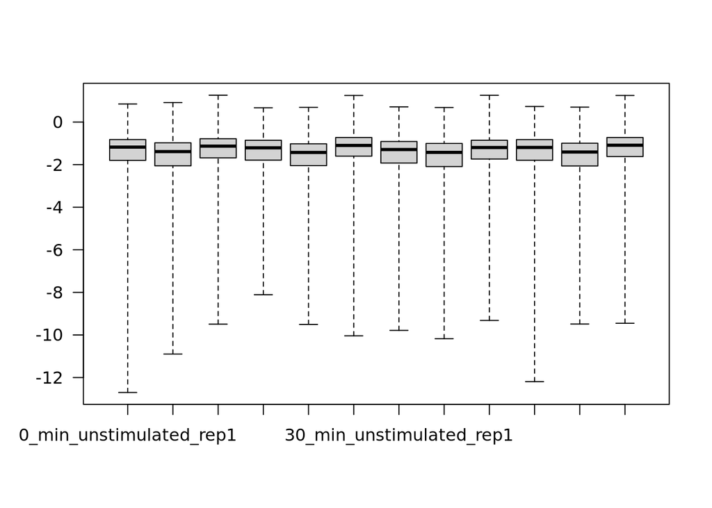

```r
boxplot(log10(assays(deData2)[["cooks"]]), range=0, las=1)
```

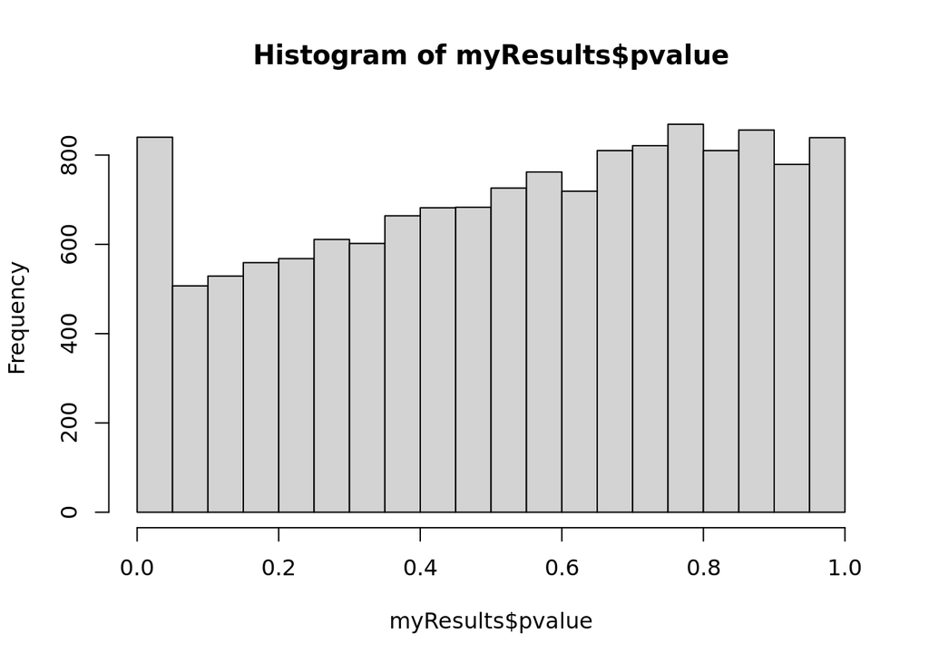

```r
hist(myResults$pvalue)
```

```r
write.csv(as.data.frame(myResults), "~/bulkRNAseq/L5/30min_n4_prn694_vs_30min_n4.csv", quote = F)

myResults2 <- results(object = deData2, contrast = c("biological_groups", "30min_N4", "30min_unstim"))
myResults2
```

```
## log2 fold change (MLE): biological_groups 30min_N4 vs 30min_unstim
## Wald test p-value: biological_groups 30min_N4 vs 30min_unstim
## DataFrame with 14247 rows and 6 columns
##                 baseMean log2FoldChange     lfcSE      stat     pvalue
##                <numeric>      <numeric> <numeric> <numeric>  <numeric>
## Zc3h14         375.46102     -0.0523502  0.197401 -0.265197 0.79085772
## Troap            4.08663      3.4141313  1.714890  1.990875 0.04649461
## 1810013L24Rik  842.63712     -0.7526271  0.487225 -1.544723 0.12241329
## Srsf7         4222.63692     -0.6388274  0.212631 -3.004401 0.00266104
## Anapc15        371.16626     -0.4134846  0.163163 -2.534185 0.01127092
## ...                  ...            ...       ...       ...        ...
## Tpm4          3634.67887      -0.415388  0.167005 -2.487278  0.0128725
## Oxgr1            2.79668       0.237437  1.192017  0.199189  0.8421147
## Gm10130         83.14188       0.417128  0.312959  1.332854  0.1825796
## Thoc2l         476.81530       0.232936  0.409457  0.568889  0.5694316
## Paqr9            1.21841       0.503513  2.320220  0.217011  0.8281998
##                    padj
##               <numeric>
## Zc3h14        0.9998040
## Troap         0.5585571
## 1810013L24Rik 0.8730702
## Srsf7         0.0845216
## Anapc15       0.2394689
## ...                 ...
## Tpm4           0.264992
## Oxgr1                NA
## Gm10130        0.988161
## Thoc2l         0.999804
## Paqr9                NA
```

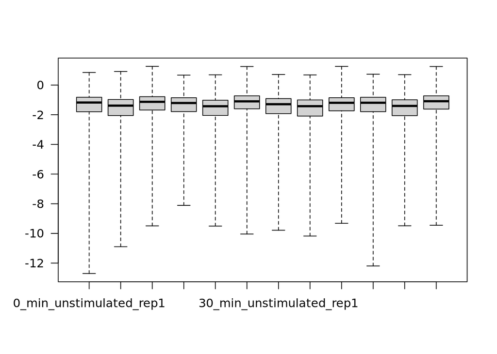

```r
boxplot(log10(assays(deData2)[["cooks"]]), range=0, las=1)
```

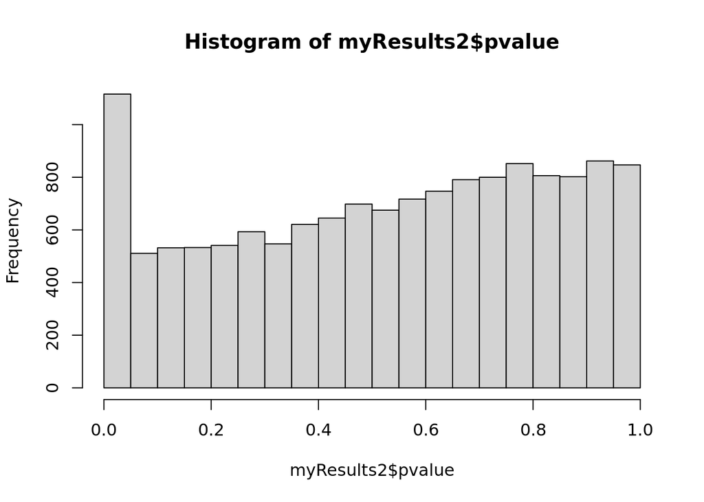

```r
hist(myResults2$pvalue)
```

```r
write.csv(as.data.frame(myResults2), "~/bulkRNAseq/L5/30min_n4_vs_30min_unstim.csv", quote = F)
```

## **Critical Thinking Exercises**

### Question 1

How many total genes were in your original input counts matrix before filtering? How many were remaining after you filtered?

geneCounts contained 25239 genes, but the new filtered matrix has 14247 genes.

### Question 2

TRUE or FALSE. DESeq2 can be used to compare relative expression levels across different genes **within** the same sample. Defend or refute your answer.

FALSE. DESeq2 cannot be used for witihin sample comparisons because normalization does not account for gene length and other within sample biases. Another normalization method would need to be utilized.

### Question 3

Why is it important to run PCA on your normalized pre-filtered gene counts data matrix?

It’s important to run PCA on your normalized, pre-filtered gene counts data matrix because comparing prior to normalization will re-introduce the potential biases we corrected for into the PCA analyses, and if we perform after filtering, that effect may be minimized and nonvisible during the PCA comparison.

### Question 4

When running differential expression analysis why is it important to look at the distribution of unadjusted p-values? What can you say about the histogram of unadjusted p-value for (a) the DE results of 30min_N4_PRN-694 relative to 30min_N4, and (b) the DE results of 30min_N4 relative to 30min_unstim. Does this seem to make sense based on the PCA? Why or why not?

It is important to look at the distribution of unadjusted p-values for (a) to see the relative frequency of genes significantly upregulated or downregulated with the addition of PRN-694 versus no inhibitor *with stimulation*, as well as compare (b) to understand the effect that stimulation alone has on the distribution of signicantly upregulated/downregulated genes. This helps us understand the potential impact the inihibtor in the context of stimulation that may/may not be explainable by stimulation alone. This is potentially explained in the PCA analysis, colored by biological group, in PC2 vs PC3, but not by PC1 vs PC2. In PC2 vs PC3, you can see a graded effect of each of the replicates shifting towards PC2 or PC3 in a linear fashion.

### Question 5

What are the top 5 down-regulated genes in the 30min_N4_PRN-694 group relative to the 30min_N4 gruop that meet an adjusted p-value < 0.05? By top 5 down-regulated I mean the top 5 most negative fold change differences.

Cd19, H2-Aa, Hck, Hpgd, C1qc.

# 4. Analysis Exercise

In the `shared-dir/data/more_datasets/` directory, you will find a file called `GSE110327_raw_count_matrix.txt.gz`. All of the following questions under the `Analysis Exercise` section will require this data set.

## STEP1: Read in counts data

Write code to read in the raw counts matrix.

```r
# TO DO

rawcounts <- read.csv(file = "~/shared-dir/data/more_datasets/GSE110327_raw_count_matrix.txt.gz", sep = "\t")
rownames(rawcounts) <- rawcounts$Geneid
newrawcounts <- rawcounts[ ,2:7]
newrawcounts
```

[output not shown]

[output cut: 33280 more lines]

[output not shown]

## STEP2: Create metadata

Write code to either read in a csv/Excel file that you made that contains the metadata that matches the counts matrix. I am requiring two pieces of metadata:

- biological replicate ID
- condition  
  *Hint: You will need to go to the GEO accession to determine the biological replicate ID for each sample since it is not listed in the counts data*

```r
# TO DO

meta <- read.csv(file = "~/bulkRNAseq/L5/metadataL5.csv", header = TRUE, sep = ",")
rownames(meta) <- meta$X
meta <- meta[,2:3]
colnames(newrawcounts) <- rownames(meta)
all(rownames(meta) == colnames(newrawcounts))
```

```
## [1] TRUE
```

```r
all(rownames(meta) %in% colnames(newrawcounts))
```

```
## [1] TRUE
```

## STEP3: Gene-level filtering

Write code to filter out genes that are not contains at least 10 reads summed across all samples.

```r
# TO DO

keep <- rowSums(newrawcounts) >= 10
filteredRawCounts <- newrawcounts[keep, ]
```

## STEP4: Normalize the Data

Remember, when we normalize the data should already be contained in a DESeq2 data object. I will walk you through the steps:

1. Write code to generate a DESeq2 object by using the filtered counts matrix and metadata you formatted in steps 1-3 above.
2. Normalized the data using DESeq2
3. Extract the normalized counts and same them into a dataframe

```r
# TO DO

#1
deData3 <- DESeqDataSetFromMatrix(countData = filteredRawCounts, colData = meta, design = ~ biological_group)
deData3 <- DESeq(deData3)
#2
normCountsDf3 <- counts(deData3, normalized = TRUE)

#3
save(normCountsDf3, file = "~/bulkRNAseq/L5/normCounts3.csv")
```

## STEP5: Perform a PCA

Write code to do the following:  
1. Perform a PCA of your normalized gene counts matrix  
2. Merge the PC values into your metadata dataframe  
3. Generate the following plots:

- scatterplot of all samples for PC1 vs PC2 colored by condition
- scatterplot of all samples for PC2 vs PC3 colored by condition
- scatterplot of all samples for PC1 vs PC2 colored by replicate
- scatterplot of all samples for PC2 vs PC3 colored by replicate

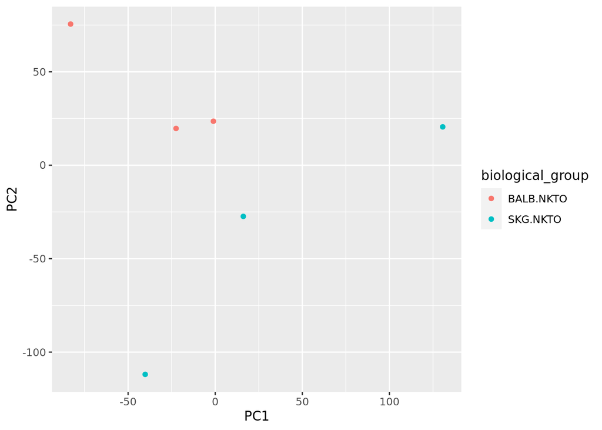

```r
# TO DO

#1
pcs3 <- prcomp(t(normCountsDf3), scale. = TRUE)

#2
meta <- cbind(pcs3$x, meta)

#3
##Plot Generation
ggplot(meta, aes(x = PC1, y = PC2, color = biological_group)) + geom_point()
```

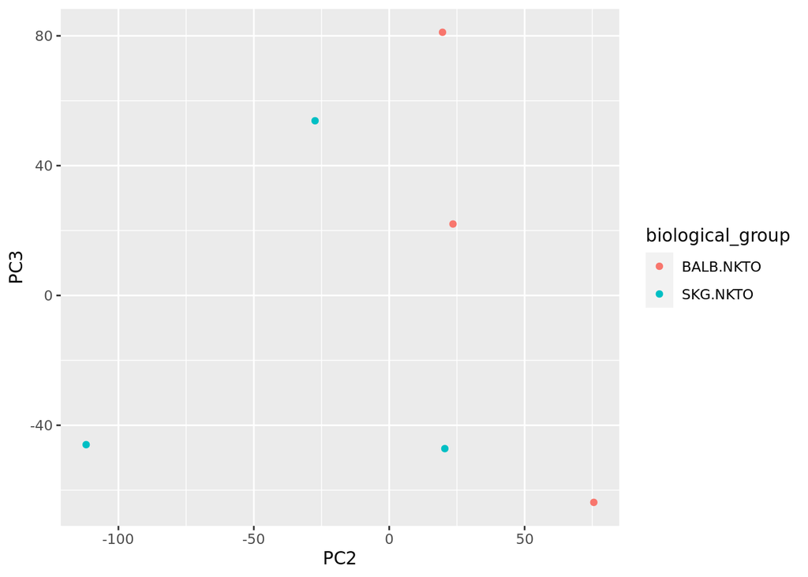

```r
ggplot(meta, aes(x = PC2, y = PC3, color = biological_group)) + geom_point()
```

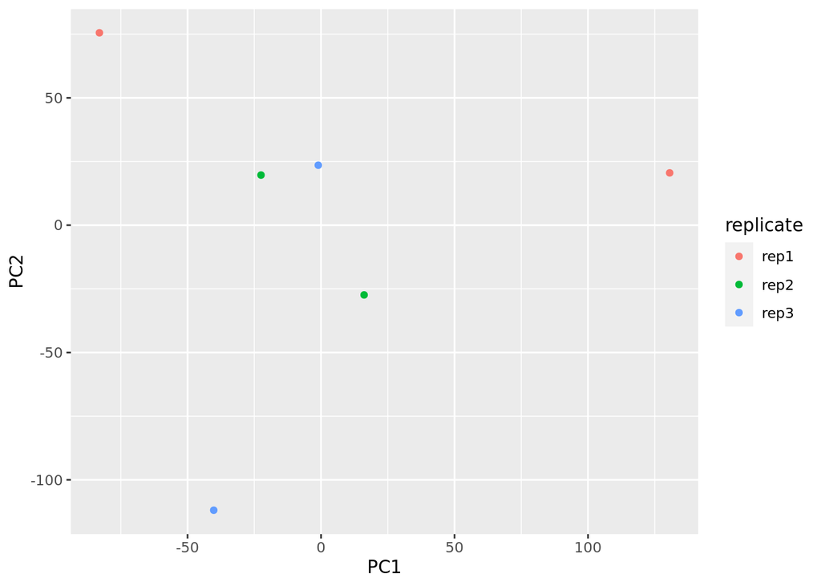

```r
ggplot(meta, aes(x = PC1, y = PC2, color = replicate)) + geom_point()
```

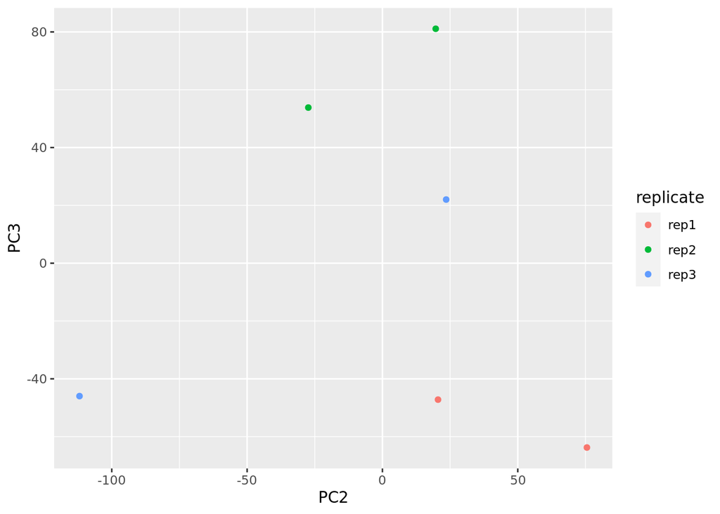

```r
ggplot(meta, aes(x = PC2, y = PC3, color = replicate)) + geom_point()
```